# FDA Challange - Mismatch Detection

Jean Ge, Josh Wildig, Luis E. Muller, Sayed Hasan, Tomal Karmakar

21/10/2018

### Introduction

Many developments have been made in biomedical research in recent years and one of the fields responsible for such achievements is the field of Genomics. Genomic research studies the structure and function of the DNA and has applications in a variety of fields including drug development, bioengineering and the study of evolutionary processes. Functional Genomics is a subfield of genomics concerned with functions and interactions of genes and proteins. Further, proteomics is specifically concerned with functions and interactions of proteins[1].

In the Cancer research field, some institutes of prevention and treatment are generating and integrating genetic data (multi-omics data) with the purpose of provide the most precise treatment for each patient. One of the many challenges that the researchers faces is the swapping of patients’ multi-omics data due to human error in different stages of data production and preliminary analysis. These errors generate mislabelled data that result in inconclusive studies[2].

The challenge and the purpose of this project is to try to detect those mislabelled samples so it can be fixed or removed from the dataset before the analysis process. To achieve such purpose, data-mining and machine learning techniques were applied in order to select the best possible model to detect mislabelled data in multi-omic dataset.

### Problem Description

FDA provided 2 distincts datasets, one for training (80 samples) another for testing (80 samples), both consisting of two files: one for the clinical data information (with information about gender and MSI) and another one with all the proteomic information (4118 protein measurements).

A swap rate of 10% was introduced in the proteomic data and 5% for the clinical data, generating in that way the mislabelled samples[2]. For the training dataset, FDA provides a file indicating which samples are mislabelled.

The challenge consists of creating a computational algorithm that can accurately detect the mislabelled samples in the test dataset.

```r
#![FDA Challenge Stage One](FDA_Challange.png)
```

### Data Exploration

First, we load the data into dataframes

```r
clinical.train = read.delim('Data/train_cli.tsv', stringsAsFactors = FALSE)
clinical.test  = read.delim('Data/test_cli.tsv', stringsAsFactors = FALSE)

proteomic.train = as.data.frame(t(read.delim('Data/train_pro.tsv')))
proteomic.test  =  as.data.frame(t(read.delim('Data/test_pro.tsv')))

mismatch = read.delim('Data/sum_tab_1.csv', sep = ',')
```

We undertake some basic preparation for classification

```r
# 0 is male low MSI, 1 is male high MSI, 2 is female low MSI and 3 is female high MSI
clinical.train$class = ifelse(clinical.train$gender == 'Female', 2, 0) + ifelse(clinical.train$msi == 'MSI-High', 1, 0)

clinical.test$class = ifelse(clinical.test$gender == 'Female', 2, 0) + ifelse(clinical.test$msi == 'MSI-High', 1, 0)

rownames(proteomic.train) = sprintf("Training_%02d", 1:80)
rownames(proteomic.test) = sprintf("Testing_%02d", 1:80)

rownames(clinical.train) = sprintf("Training_%02d", 1:80)
rownames(clinical.test) = sprintf("Testing_%02d", 1:80)

clinical.train.correct = clinical.train[!mismatch$mismatch,]
```

The proteomic data have 4118 different protein measurements and most of them are not completed (have NAs - missing values) as illustrated below:

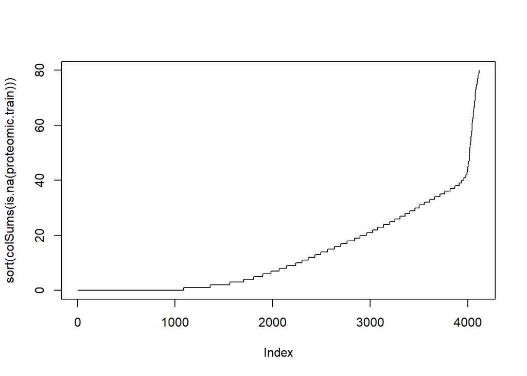

```r
plot(sort(colSums(is.na(proteomic.train))), type = 'l')
```

The clinical data has two binary features for each sample: gender (‘Male’/‘Female’) and MSI (‘High-MSI’/‘Low-MSI/MSS’). The class distributions are highly unbalanced as we visualise below:

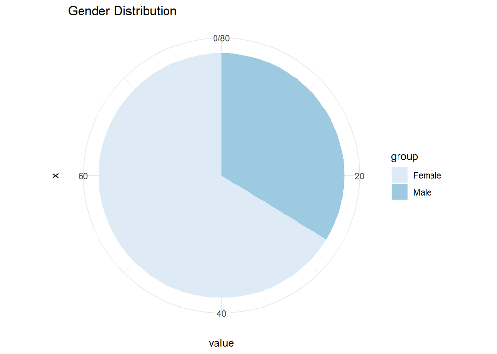

```r
library(plyr)
dfgender <- count(clinical.train, c('gender'))
#dfgender
df_msi <- count(clinical.train, c('msi'))
#df_msi

library(ggplot2)
df <- data.frame(
 group = c("Female", "Male"),
 value = c(dfgender[1,2], dfgender[2,2])
)

df2 <- data.frame(
 group = c("MSI-High", "MSI-Low"),
 value = c(df_msi[1,2], df_msi[2,2])
)


bp <- ggplot(df, aes(x="", y=value, fill=group))+
geom_bar(width = 1, stat = "identity")
pie <- bp + coord_polar("y", start=0) + scale_fill_brewer(palette="Blues")+
 theme_minimal() + ggtitle("Gender Distribution")



bp2 <- ggplot(df2, aes(x="", y=value, fill=group)) +
geom_bar(width = 1, stat = "identity")
pie2 <- bp2 + coord_polar("y", start=0) + scale_fill_brewer(palette="")+
 theme_minimal() + ggtitle("MSI Distribution")
pie
```

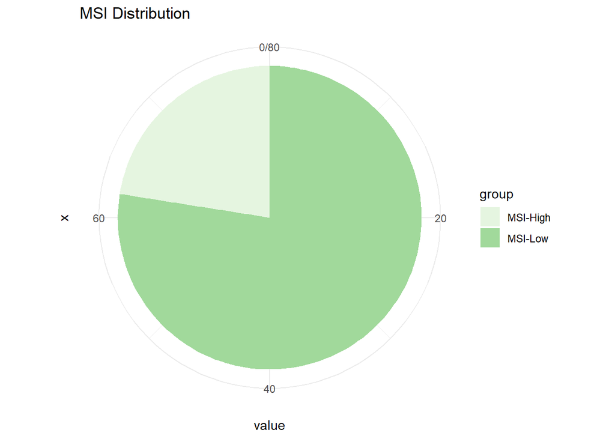

```r
pie2
```

```r
table(factor(clinical.train$class, levels = c(0, 1, 2, 3), labels = c('Male-Low', 'Male-High', 'Female-Low', 'Female-High')))
```

```
##
##    Male-Low   Male-High  Female-Low Female-High
##          22           5          40          13
```

### Feature Selection

#### Impute sample values

```r
# Impute a dataframe with the minimum value per column
imputedf = function(x) {
  df = x
  for (i in 1:ncol(x)) {
     if (is.numeric(df[,i])) {
        df[which(is.na(df[,i])),i] = 0
      }
  }
  df
}

# Remove any columns which will be constant on imputation
remove = which(colSums(!is.na(proteomic.train)) < 2)

# Combine train and test sets together
proteomic.both = rbind(proteomic.train, proteomic.test)

# Impute train and test columns with the same value
proteomic.both.imputed = imputedf(proteomic.both)

# Split the imputed dataframe
proteomic.train.imputed = proteomic.both.imputed[1:80,-remove]
proteomic.test.imputed = proteomic.both.imputed[81:160,-remove]




# Find the correctly labelled samples
proteomic.train.imputed.correct = proteomic.train.imputed[!mismatch$mismatch,]
```

#### Filter feature selection

```r
# Split the train data two ways: once by gender and once by MSI
proteomic.train.imputed.by.gender  = split(proteomic.train.imputed, clinical.train$gender)
proteomic.train.imputed.by.msi     = split(proteomic.train.imputed, clinical.train$msi)


gender.pvalues = c()
msi.pvalues    = c()

# Calculate p values for the t-test on whether the means of the protein values are different when splitting by gender
for (i in 1:ncol(proteomic.train.imputed)) {
  gender.pvalues = c(gender.pvalues, t.test(proteomic.train.imputed.by.gender[[1]][,i], proteomic.train.imputed.by.gender[[2]][,i])$p.value)
}

# Calculate p values for the t-test on whether the means of the protein values are different when splitting by msi
for (i in 1:ncol(proteomic.train.imputed)) {
  msi.pvalues = c(msi.pvalues, t.test(proteomic.train.imputed.by.msi[[1]][,i], proteomic.train.imputed.by.msi[[2]][,i])$p.value)
}

# Add appropriate names to p values
names(gender.pvalues) = colnames(proteomic.train.imputed)
names(msi.pvalues)    = colnames(proteomic.train.imputed)

# Select 100 features to keep based on each set of t tests
keep.gender = names(sort(gender.pvalues))[1:100]
keep.msi    = names(sort(msi.pvalues))[1:100]

# Find the union of the two lists of features to keep
keep = union(keep.gender, keep.msi)

# The final training dataset
proteomic.train.imputed.correct.keep = proteomic.train.imputed[!mismatch$mismatch, keep]
```

#### Wrapper Feature Selection

```r
# Load important libraries
library(e1071)
library(caret)
nfolds = 5
nvars = dim(proteomic.train.imputed.correct.keep)[2]

set.seed(1)


folds = createFolds(clinical.train.correct$class, nfolds)

maxvars = 5

include = c()
acc.n = numeric(length = maxvars)


for (k in 1:maxvars) {
  acc.include = numeric(nvars)
  p.names = colnames(proteomic.train.imputed.correct.keep)
  names(acc.include) = p.names


  tocheck = p.names[-which(p.names %in% include)]


  for (t in tocheck) {
    includetest = c(include, t)
    cls = clinical.train.correct$class
    train = cbind(proteomic.train.imputed.correct.keep[,includetest], cls)
    acc.folds = numeric(length = nfolds)

    for (i in 1:nfolds) {

      svm.model = svm(factor(cls) ~ ., data = train[-folds[[i]],])
      preds = predict(svm.model, newdata = train[folds[[i]],])
      acc.folds[i] = mean(preds == cls[folds[[i]]])
    }

    acc.include[t] = mean(acc.folds)
  }
  toinclude = names(which.max(acc.include))
  acc.n[k]  = max(acc.include)
  include   = c(include, toinclude)
  print(include)
}
```

```
## [1] "DDX3Y"
## [1] "DDX3Y"  "UBE2L6"
## [1] "DDX3Y"  "UBE2L6" "RPS4Y1"
## [1] "DDX3Y"    "UBE2L6"   "RPS4Y1"   "ARHGEF16"
## [1] "DDX3Y"    "UBE2L6"   "RPS4Y1"   "ARHGEF16" "ARSE"
```

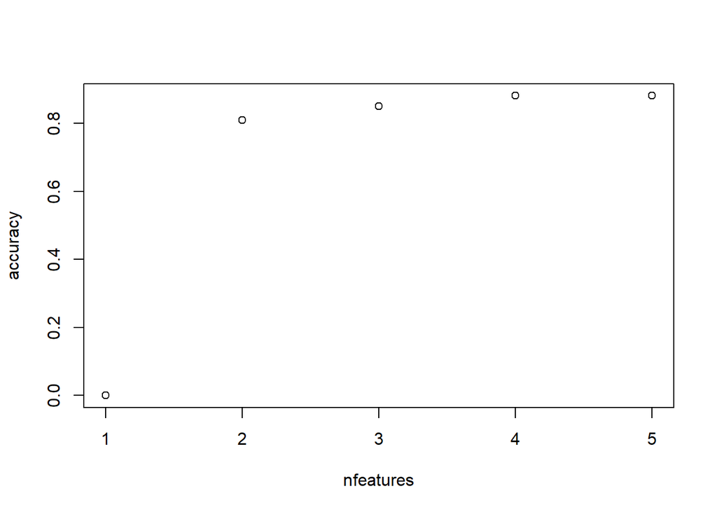

```r
plot(1:length(acc.n), acc.n, xlab = 'nfeatures', ylab = 'accuracy')
```

```r
#include = c("DDX3Y", "UBE2L6", "RPS4Y1","ARHGEF16","ARSE")
```

### Classification Approach

```r
svm.model = svm(factor(cls) ~ ., data = proteomic.train.imputed.correct[,include], probability = TRUE)


preds.train = predict(svm.model, newdata = proteomic.train.imputed[, include], probability = TRUE)
preds.test = predict(svm.model, newdata = proteomic.test.imputed[,include], probability = TRUE)


preds.miscl.train = ifelse(preds.train != clinical.train$class, 1, 0)


recall(factor(preds.miscl.train), factor(mismatch$mismatch))
```

```
## [1] 0.8676471
```

```r
precision(factor(preds.miscl.train), factor(mismatch$mismatch))
```

```
## [1] 0.9672131
```

```r
F_meas(factor(preds.miscl.train), factor(mismatch$mismatch))
```

```
## [1] 0.9147287
```

```r
preds.train.correct = predict(svm.model, newdata = proteomic.train.imputed.correct[,include], probability = TRUE)

acc.cl = numeric(4)
recall.cl = numeric(4)
precision.cl = numeric(4)
F1.cl = numeric(4)

for (cl in 0:3) {
  preds.cl.correct = ifelse(preds.train.correct == cl, 1, 0)
  truth.cl.correct = ifelse(clinical.train.correct$class == cl, 1, 0)

  TP = sum((preds.cl.correct == truth.cl.correct)[preds.cl.correct == 1])
  TN = sum((preds.cl.correct == truth.cl.correct)[preds.cl.correct == 0])
  FP = sum((preds.cl.correct != truth.cl.correct)[preds.cl.correct == 1])
  FN = sum((preds.cl.correct != truth.cl.correct)[preds.cl.correct == 0])

  acc.cl[cl + 1] = (TP + TN) / (TP + TN + FP + FN)
  recall.cl[cl + 1] = TP/(TP + FN)
  precision.cl[cl + 1] = TP/(TP + FP)
  F1.cl[cl + 1] = 2*TP/(2*TP + FN + FP)
}


mean(preds.miscl.train == mismatch$mismatch)
```

```
## [1] 0.8625
```

```r
mean(preds.train == clinical.train$class)
```

```
## [1] 0.7625
```

```r
mean(preds.test == clinical.test$class)
```

```
## [1] 0.65
```

```r
names(recall.cl) = 0:3
names(precision.cl) = 0:3
names(F1.cl) = 0:3
names(acc.cl) = 0:3

results = data.frame(rbind(recall.cl,precision.cl,F1.cl, acc.cl ))
colnames(results) = 0:3
rownames(results) = c('recall', 'precision', 'F1', 'accuracy')
results
```

```
##                   0         1         2         3
## recall    0.9500000 0.0000000 0.9705882 0.7777778
## precision 0.7916667       NaN 0.9166667 0.8750000
## F1        0.8636364 0.0000000 0.9428571 0.8235294
## accuracy  0.9117647 0.9264706 0.9411765 0.9558824
```

### Evaluation

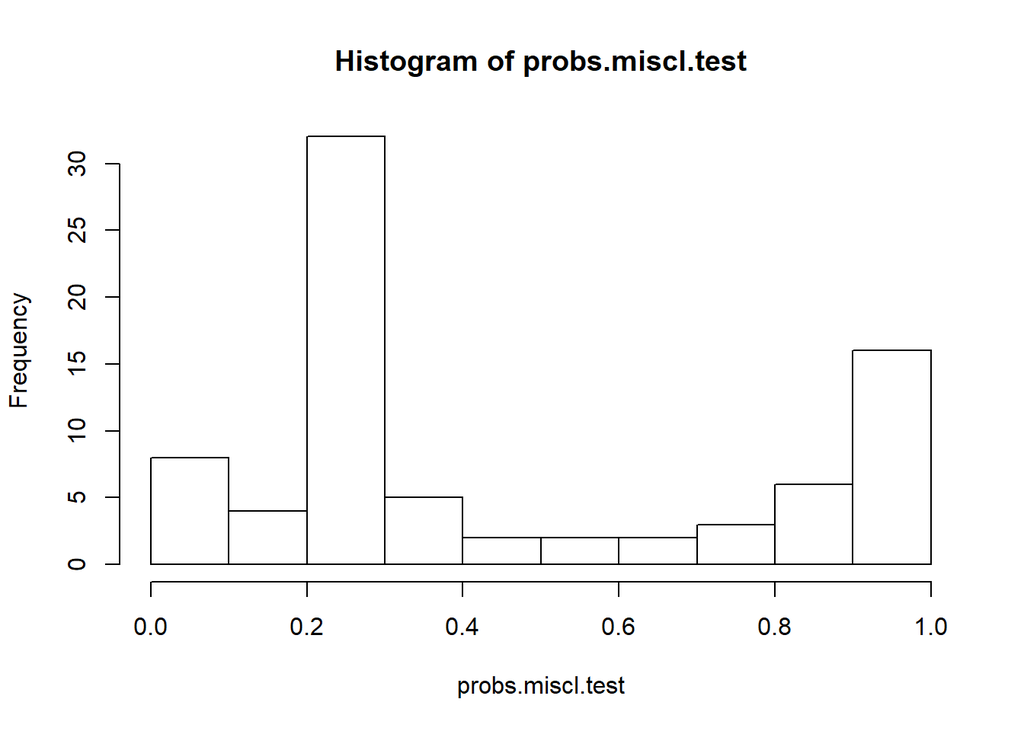

```r
probs.test = attr(preds.test, 'probabilities')

probs.test = probs.test[,c(2,3,1,4)]

probs.miscl.test = numeric(length = 80)

for (s in 1:80) {
  probs.miscl.test[s] = 1 - probs.test[s,clinical.test$class[s] + 1]
}

hist(probs.miscl.test)
```

```r
preds.miscl.test = ifelse(probs.miscl.test > 0.5, 1, 0)
cbind(probs.miscl.test, preds.miscl.test)
```

```
##       probs.miscl.test preds.miscl.test
##  [1,]       0.23731283                0
##  [2,]       0.22293076                0
##  [3,]       0.47087247                0
##  [4,]       0.91541054                1
##  [5,]       0.38451772                0
##  [6,]       0.91200995                1
##  [7,]       0.28052642                0
##  [8,]       0.95970741                1
##  [9,]       0.99066729                1
## [10,]       0.07548898                0
## [11,]       0.93317870                1
## [12,]       0.64556017                1
## [13,]       0.25448642                0
## [14,]       0.23978691                0
```

[output cut: 66 more lines]

### Two class Approach

#### Clean and process train data

#### Clean and process test data

#### Filter Correct labelled data

#### Wrapper feature selection (Forward stepwise selection)

```
## [1] "Top features for Gender (Male/Female)"
```

```
##  [1] "DDX3Y"  "CANT1"  "RPS4Y1" "UBA1"   "PQBP1"  "SYNM"   "ASB9"
##  [8] "P02769" "CORO1C" "TLN1"   "ACTA2"  "NAP1L1" "DDX3X"  "RBPMS"
## [15] "FAM3D"  "ACTG2"  "DYNLL1" "WFS1"   "ATP8B1" "TNPO2"
```

```
## [1] "Top features for msi (MSI-Low/MSS or MSI-High ):"
```

```
##  [1] "LMNA"    "GBP1"    "HK3"     "NUBPL"   "PTPRC"   "STAT1"   "DPEP1"
##  [8] "ITGB2"   "LCP1"    "ARHGDIB" "TMLHE"   "PARP14"  "TAPBP"   "ACOT8"
## [15] "WARS"    "PSMB9"   "MCM3"    "NCF2"    "PARP9"   "HNF4A"
```

#### Analyse accuracy and choose appropriate number of features for label Gender(Male/Female) from that

```
##  [1] "DDX3Y"  "CANT1"  "RPS4Y1" "UBA1"   "PQBP1"  "SYNM"   "ASB9"
##  [8] "P02769" "CORO1C" "TLN1"   "ACTA2"  "NAP1L1" "DDX3X"  "RBPMS"
## [15] "FAM3D"  "ACTG2"  "DYNLL1" "WFS1"   "ATP8B1" "TNPO2"
```

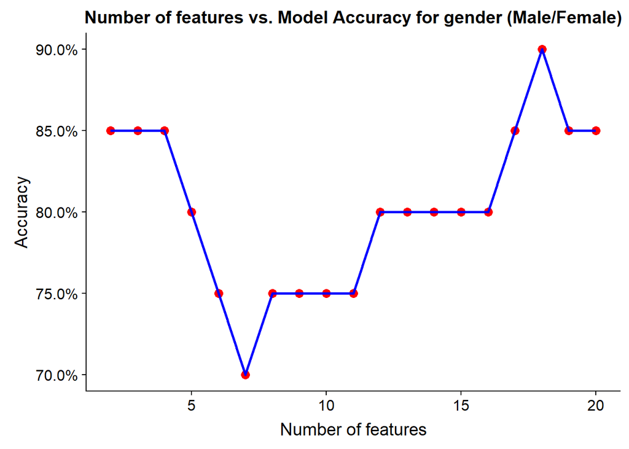

#### Analyse accuracy and choose appropriate number of features for label msi ()

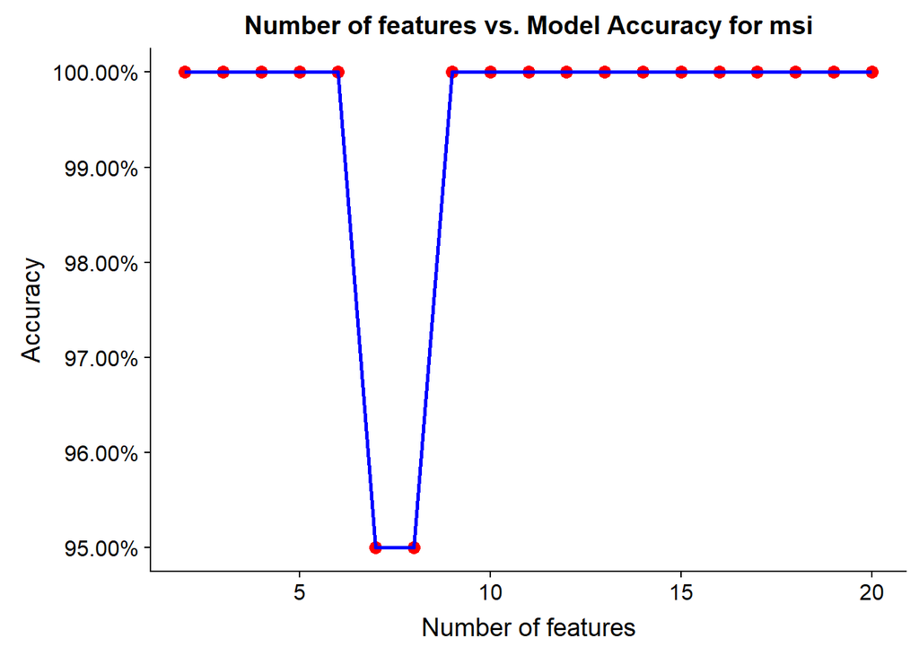

#### Classify Gender (Male/Female) of 68 Correct Train data

```
##                cls.test
## knn.fit.labele1  0  1
##               0 11  4
##               1  1  4
```

```
## [1] "Mean F1 Score:  0.615384615384615"
```

```
## [1] "Accuracy on train correctly labelled data for (male/female): 0.911764705882353"
```

#### Predict Gender (Male/Female) of Test Data

```
## [1] "Accuracy of predicting gender in test Data: 0.7875"
```

```
## [1] "Number of correct gender in test data: 63"
```

#### Predict Gender (Male/Female) of all train 80 Data

```
## [1] "Accuracy of predicting gender in train all 80 Data: 0.9125"
```

```
## [1] "Number of correct gender in test data: 73"
```

#### Classify Label MSI (MSI-Low/MSS or MSI-High) to using top 4 wrapper selected features

```
##               cls.test
## knn.fit.label2  0  1
##              0 18  0
##              1  0  2
```

```
## [1] "Accuracy of label (MSI) for train correctly labelled data:  0.970588235294118"
```

```
## [1] "F1 Score for MSI of train data:  0.928571428571429"
```

#### Combined Gender and MSI to and check with train correctly labelled 68 data

```
## [1] "Accuracy of Gender and MSI together for train correctly labelled data:  0.882352941176471"
```

#### Question2: A predicted list of mislabelled samples from training data

```
## [1] "Accuracy of predicting gender in train all 80 Data: 0.9125"
```

```
## [1] "Number of correct gender in test data: 73"
```

```
## [1] "table of label (gender and MSI) mismatch for train 80 data comapare with graound truth:"
```

```
##
##      0  1
##   0 65  3
##   1  2 10
```

```
## [1] "Number of mislabelled samples of train 80 data predicted by our model : 13"
```

#### Predict MSI (MSI-Low/MSS or MSI-High) of Test Data

```
## [1] "Accuracy of label2 (MSI) for  test data:  0.8125"
```

[output not shown]

```
## [1] "Number of mislabelled samples of test 80 data predicted by our model : 28"
```

```
## [1] "Accuracy for  Gender (Male/Female) of train using Ada Sampling: 0.90625"
```

```
## [1] "F1 Score for Gender (Male/Female) of train data using Ada Sampling:  0.88"
```

```
## [1] "Accuracy for label MSI of all train data using Ada Sampling: 0.96875"
```

```
## [1] "F1 Score for MSI of all train data using Ada Sampling:  0.933333333333333"
```

#### AdaSampling to predict Gender(Male/Female) 80 test data

```
## [1] "Number of correctly predicted Gender in test data: 61"
```

[output not shown]

```
## [1] "F1 Score for Gender (Male/Female) of test data using Ada Sampling:  0.786516853932584"
```

#### AdaSampling to predict MSI 80 test data

```
## [1] "Number of correct MSI in test data: 65"
```

```
##          pred.label2.ada
## test.cls2  0  1
##         0 60  6
##         1  9  5
```

```
## [1] "Accuracy for  MSI of test data using Ada Sampling: 0.8125"
```

```
## [1] "F1 Score for MSI of test data using Ada Sampling: 0.4"
```

```
## [1] "Number of Test data predicted as correctly labelelled both Gender and MSI : 51"
```